# Optimal Treatment Analysis

## Outcome Variable

**Outcome Variable:** haz

## Predictor Variables

**Intervention Variable:** safeh20

**Adjustment Set:**

- arm
- sex
- W_mage
- meducyrs
- feducyrs
- hhwealth_quart
- hfoodsec
- W_mhtcm
- W_mwtkg
- W_mbmi
- W_nrooms
- W_nchldlt5
- W_parity
- impfloor
- impsan
- delta_W_mage
- delta_meducyrs
- delta_feducyrs
- delta_hhwealth_quart
- delta_hfoodsec
- delta_W_mhtcm
- delta_W_mwtkg
- delta_W_mbmi
- delta_W_nrooms
- delta_W_nchldlt5
- delta_W_parity
- delta_impfloor
- delta_impsan

## Stratifying Variables

The analysis was stratified on these variable(s):

- agecat
- studyid
- country

## Data Summary

| agecat | studyid | country | safeh20 | n_cell | n |
| --- | --- | --- | --- | --- | --- |
| Birth | ki0047075b-MAL-ED | BANGLADESH | 1 | 0 | 213 |
| Birth | ki0047075b-MAL-ED | BANGLADESH | 0 | 213 | 213 |
| Birth | ki0047075b-MAL-ED | BRAZIL | 1 | 0 | 41 |
| Birth | ki0047075b-MAL-ED | BRAZIL | 0 | 41 | 41 |
| Birth | ki0047075b-MAL-ED | INDIA | 1 | 0 | 41 |
| Birth | ki0047075b-MAL-ED | INDIA | 0 | 41 | 41 |
| Birth | ki0047075b-MAL-ED | NEPAL | 1 | 1 | 26 |
| Birth | ki0047075b-MAL-ED | NEPAL | 0 | 25 | 26 |
| Birth | ki0047075b-MAL-ED | PERU | 1 | 9 | 207 |
| Birth | ki0047075b-MAL-ED | PERU | 0 | 198 | 207 |
| Birth | ki0047075b-MAL-ED | SOUTH AFRICA | 1 | 13 | 96 |
| Birth | ki0047075b-MAL-ED | SOUTH AFRICA | 0 | 83 | 96 |
| Birth | ki0047075b-MAL-ED | TANZANIA, UNITED REPUBLIC OF | 1 | 79 | 119 |
| Birth | ki0047075b-MAL-ED | TANZANIA, UNITED REPUBLIC OF | 0 | 40 | 119 |
| Birth | ki1017093-NIH-Birth | BANGLADESH | 1 | 606 | 608 |
| Birth | ki1017093-NIH-Birth | BANGLADESH | 0 | 2 | 608 |
| Birth | ki1017093b-PROVIDE | BANGLADESH | 1 | 45 | 45 |
| Birth | ki1017093b-PROVIDE | BANGLADESH | 0 | 0 | 45 |
| Birth | ki1017093c-NIH-Crypto | BANGLADESH | 1 | 732 | 732 |
| Birth | ki1017093c-NIH-Crypto | BANGLADESH | 0 | 0 | 732 |
| Birth | kiGH5241-JiVitA-3 | BANGLADESH | 1 | 22392 | 22432 |
| Birth | kiGH5241-JiVitA-3 | BANGLADESH | 0 | 40 | 22432 |
| Birth | kiGH5241-JiVitA-4 | BANGLADESH | 1 | 2820 | 2820 |
| Birth | kiGH5241-JiVitA-4 | BANGLADESH | 0 | 0 | 2820 |
| 6 months | ki0047075b-MAL-ED | BANGLADESH | 1 | 0 | 240 |
| 6 months | ki0047075b-MAL-ED | BANGLADESH | 0 | 240 | 240 |
| 6 months | ki0047075b-MAL-ED | BRAZIL | 1 | 0 | 142 |
| 6 months | ki0047075b-MAL-ED | BRAZIL | 0 | 142 | 142 |
| 6 months | ki0047075b-MAL-ED | INDIA | 1 | 0 | 235 |
| 6 months | ki0047075b-MAL-ED | INDIA | 0 | 235 | 235 |

[output cut: 52 more lines]

The following strata were considered:

- agecat: 24 months, studyid: ki0047075b-MAL-ED, country: BANGLADESH
- agecat: 24 months, studyid: ki0047075b-MAL-ED, country: BRAZIL
- agecat: 24 months, studyid: ki0047075b-MAL-ED, country: INDIA
- agecat: 24 months, studyid: ki0047075b-MAL-ED, country: NEPAL
- agecat: 24 months, studyid: ki0047075b-MAL-ED, country: PERU
- agecat: 24 months, studyid: ki0047075b-MAL-ED, country: SOUTH AFRICA
- agecat: 24 months, studyid: ki0047075b-MAL-ED, country: TANZANIA, UNITED REPUBLIC OF
- agecat: 24 months, studyid: ki1017093-NIH-Birth, country: BANGLADESH
- agecat: 24 months, studyid: ki1017093b-PROVIDE, country: BANGLADESH
- agecat: 24 months, studyid: ki1017093c-NIH-Crypto, country: BANGLADESH
- agecat: 24 months, studyid: ki1114097-CONTENT, country: PERU
- agecat: 24 months, studyid: ki1148112-LCNI-5, country: MALAWI
- agecat: 24 months, studyid: kiGH5241-JiVitA-3, country: BANGLADESH
- agecat: 24 months, studyid: kiGH5241-JiVitA-4, country: BANGLADESH
- agecat: 6 months, studyid: ki0047075b-MAL-ED, country: BANGLADESH
- agecat: 6 months, studyid: ki0047075b-MAL-ED, country: BRAZIL
- agecat: 6 months, studyid: ki0047075b-MAL-ED, country: INDIA
- agecat: 6 months, studyid: ki0047075b-MAL-ED, country: NEPAL
- agecat: 6 months, studyid: ki0047075b-MAL-ED, country: PERU
- agecat: 6 months, studyid: ki0047075b-MAL-ED, country: SOUTH AFRICA
- agecat: 6 months, studyid: ki0047075b-MAL-ED, country: TANZANIA, UNITED REPUBLIC OF
- agecat: 6 months, studyid: ki1000304b-SAS-FoodSuppl, country: INDIA
- agecat: 6 months, studyid: ki1017093-NIH-Birth, country: BANGLADESH
- agecat: 6 months, studyid: ki1017093b-PROVIDE, country: BANGLADESH
- agecat: 6 months, studyid: ki1017093c-NIH-Crypto, country: BANGLADESH
- agecat: 6 months, studyid: ki1114097-CONTENT, country: PERU
- agecat: 6 months, studyid: ki1148112-LCNI-5, country: MALAWI
- agecat: 6 months, studyid: kiGH5241-JiVitA-3, country: BANGLADESH
- agecat: 6 months, studyid: kiGH5241-JiVitA-4, country: BANGLADESH
- agecat: Birth, studyid: ki0047075b-MAL-ED, country: BANGLADESH
- agecat: Birth, studyid: ki0047075b-MAL-ED, country: BRAZIL
- agecat: Birth, studyid: ki0047075b-MAL-ED, country: INDIA
- agecat: Birth, studyid: ki0047075b-MAL-ED, country: NEPAL
- agecat: Birth, studyid: ki0047075b-MAL-ED, country: PERU
- agecat: Birth, studyid: ki0047075b-MAL-ED, country: SOUTH AFRICA
- agecat: Birth, studyid: ki0047075b-MAL-ED, country: TANZANIA, UNITED REPUBLIC OF
- agecat: Birth, studyid: ki1017093-NIH-Birth, country: BANGLADESH
- agecat: Birth, studyid: ki1017093b-PROVIDE, country: BANGLADESH
- agecat: Birth, studyid: ki1017093c-NIH-Crypto, country: BANGLADESH
- agecat: Birth, studyid: kiGH5241-JiVitA-3, country: BANGLADESH
- agecat: Birth, studyid: kiGH5241-JiVitA-4, country: BANGLADESH

### Dropped Strata

- agecat: Birth, studyid: ki0047075b-MAL-ED, country: BANGLADESH
- agecat: Birth, studyid: ki0047075b-MAL-ED, country: BRAZIL
- agecat: Birth, studyid: ki0047075b-MAL-ED, country: INDIA
- agecat: Birth, studyid: ki0047075b-MAL-ED, country: NEPAL
- agecat: Birth, studyid: ki1017093-NIH-Birth, country: BANGLADESH
- agecat: Birth, studyid: ki1017093b-PROVIDE, country: BANGLADESH
- agecat: Birth, studyid: ki1017093c-NIH-Crypto, country: BANGLADESH
- agecat: Birth, studyid: kiGH5241-JiVitA-4, country: BANGLADESH
- agecat: 6 months, studyid: ki0047075b-MAL-ED, country: BANGLADESH
- agecat: 6 months, studyid: ki0047075b-MAL-ED, country: BRAZIL
- agecat: 6 months, studyid: ki0047075b-MAL-ED, country: INDIA
- agecat: 6 months, studyid: ki0047075b-MAL-ED, country: NEPAL
- agecat: 6 months, studyid: ki1000304b-SAS-FoodSuppl, country: INDIA
- agecat: 6 months, studyid: ki1017093-NIH-Birth, country: BANGLADESH
- agecat: 6 months, studyid: ki1017093b-PROVIDE, country: BANGLADESH
- agecat: 6 months, studyid: ki1017093c-NIH-Crypto, country: BANGLADESH
- agecat: 6 months, studyid: ki1114097-CONTENT, country: PERU
- agecat: 6 months, studyid: kiGH5241-JiVitA-4, country: BANGLADESH
- agecat: 24 months, studyid: ki0047075b-MAL-ED, country: BANGLADESH
- agecat: 24 months, studyid: ki0047075b-MAL-ED, country: BRAZIL
- agecat: 24 months, studyid: ki0047075b-MAL-ED, country: INDIA
- agecat: 24 months, studyid: ki0047075b-MAL-ED, country: NEPAL
- agecat: 24 months, studyid: ki1017093-NIH-Birth, country: BANGLADESH
- agecat: 24 months, studyid: ki1017093b-PROVIDE, country: BANGLADESH
- agecat: 24 months, studyid: ki1017093c-NIH-Crypto, country: BANGLADESH
- agecat: 24 months, studyid: ki1114097-CONTENT, country: PERU
- agecat: 24 months, studyid: kiGH5241-JiVitA-4, country: BANGLADESH

## Methods Detail

We’re interested in the causal parameters $E[Y_a]$ for all values of $a \in \mathcal{A}$. These parameters represent the mean outcome if, possibly contrary to fact, we intervened to set all units to have $A=a$. Under the randomization and positivity assumptions, these are identified by the statistical parameters $\psi_a=E_W[E_{Y|A,W}(Y|A=a,W)]$. In addition, we’re interested in the mean of $Y$, $E[Y]$ under no intervention (the observed mean). We will estimate these parameters by using SuperLearner to fit the relevant likelihood factors – $E_{Y|A,W}(Y|A=a,W)$ and $p(A=a|W)$, and then updating our likelihood fit using a joint TMLE.

For unadjusted analyses ($W=\{\}$), initial likelihoods were estimated using Lrnr_glm to estimate the simple $E(Y|A)$ and Lrnr_mean to estimate $p(A)$. For adjusted analyses, a small library containing Lrnr_glmnet, Lrnr_xgboost, and Lrnr_mean was used.

# Results Detail

## Results Plots

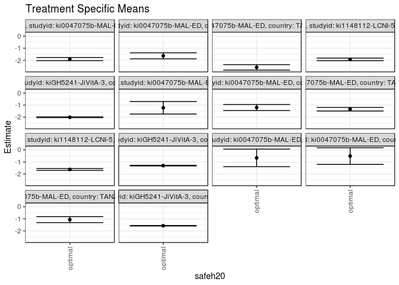

## Results Table

### Parameter: TSM

| agecat | studyid | country | intervention_level | baseline_level | estimate | ci_lower | ci_upper |
| --- | --- | --- | --- | --- | --- | --- | --- |
| Birth | ki0047075b-MAL-ED | PERU | optimal | observed | -0.6596567 | -1.386360 | 0.0670465 |
| Birth | ki0047075b-MAL-ED | SOUTH AFRICA | optimal | observed | -0.5097551 | -1.194026 | 0.1745161 |
| Birth | ki0047075b-MAL-ED | TANZANIA, UNITED REPUBLIC OF | optimal | observed | -1.0660572 | -1.314463 | -0.8176510 |
| Birth | kiGH5241-JiVitA-3 | BANGLADESH | optimal | observed | -1.5745618 | -1.594222 | -1.5549017 |
| 6 months | ki0047075b-MAL-ED | PERU | optimal | observed | -1.2237355 | -1.742180 | -0.7052907 |
| 6 months | ki0047075b-MAL-ED | SOUTH AFRICA | optimal | observed | -1.2013408 | -1.452186 | -0.9504959 |
| 6 months | ki0047075b-MAL-ED | TANZANIA, UNITED REPUBLIC OF | optimal | observed | -1.3406350 | -1.489526 | -1.1917438 |
| 6 months | ki1148112-LCNI-5 | MALAWI | optimal | observed | -1.6201714 | -1.697261 | -1.5430813 |
| 6 months | kiGH5241-JiVitA-3 | BANGLADESH | optimal | observed | -1.3055944 | -1.330773 | -1.2804158 |
| 24 months | ki0047075b-MAL-ED | PERU | optimal | observed | -1.9021570 | -2.032309 | -1.7720055 |
| 24 months | ki0047075b-MAL-ED | SOUTH AFRICA | optimal | observed | -1.6323018 | -1.881365 | -1.3832388 |
| 24 months | ki0047075b-MAL-ED | TANZANIA, UNITED REPUBLIC OF | optimal | observed | -2.5891481 | -2.814221 | -2.3640753 |
| 24 months | ki1148112-LCNI-5 | MALAWI | optimal | observed | -1.9275788 | -2.035028 | -1.8201295 |
| 24 months | kiGH5241-JiVitA-3 | BANGLADESH | optimal | observed | -2.0086753 | -2.037096 | -1.9802544 |

### Parameter: E(Y)

| agecat | studyid | country | intervention_level | baseline_level | estimate | ci_lower | ci_upper |
| --- | --- | --- | --- | --- | --- | --- | --- |
| Birth | ki0047075b-MAL-ED | PERU | observed | observed | -0.8950725 | -1.0180716 | -0.7720734 |
| Birth | ki0047075b-MAL-ED | SOUTH AFRICA | observed | observed | -0.5523958 | -0.7550074 | -0.3497843 |
| Birth | ki0047075b-MAL-ED | TANZANIA, UNITED REPUBLIC OF | observed | observed | -1.1158824 | -1.3283278 | -0.9034369 |
| Birth | kiGH5241-JiVitA-3 | BANGLADESH | observed | observed | -1.5896835 | -1.6089596 | -1.5704074 |
| 6 months | ki0047075b-MAL-ED | PERU | observed | observed | -1.3065026 | -1.4164323 | -1.1965728 |
| 6 months | ki0047075b-MAL-ED | SOUTH AFRICA | observed | observed | -1.0533804 | -1.1834360 | -0.9233247 |
| 6 months | ki0047075b-MAL-ED | TANZANIA, UNITED REPUBLIC OF | observed | observed | -1.3658943 | -1.4882808 | -1.2435078 |
| 6 months | ki1148112-LCNI-5 | MALAWI | observed | observed | -1.6426961 | -1.7120603 | -1.5733318 |
| 6 months | kiGH5241-JiVitA-3 | BANGLADESH | observed | observed | -1.3132090 | -1.3363486 | -1.2900693 |
| 24 months | ki0047075b-MAL-ED | PERU | observed | observed | -1.7529793 | -1.8786399 | -1.6273186 |
| 24 months | ki0047075b-MAL-ED | SOUTH AFRICA | observed | observed | -1.6471273 | -1.7822999 | -1.5119547 |
| 24 months | ki0047075b-MAL-ED | TANZANIA, UNITED REPUBLIC OF | observed | observed | -2.6488498 | -2.7844961 | -2.5132034 |
| 24 months | ki1148112-LCNI-5 | MALAWI | observed | observed | -1.8822648 | -1.9637218 | -1.8008078 |
| 24 months | kiGH5241-JiVitA-3 | BANGLADESH | observed | observed | -2.0135591 | -2.0412422 | -1.9858759 |

### Parameter: PAR

| agecat | studyid | country | intervention_level | baseline_level | estimate | ci_lower | ci_upper |
| --- | --- | --- | --- | --- | --- | --- | --- |
| Birth | ki0047075b-MAL-ED | PERU | optimal | observed | -0.2354157 | -0.9463274 | 0.4754960 |
| Birth | ki0047075b-MAL-ED | SOUTH AFRICA | optimal | observed | -0.0426407 | -0.6709873 | 0.5857058 |
| Birth | ki0047075b-MAL-ED | TANZANIA, UNITED REPUBLIC OF | optimal | observed | -0.0498251 | -0.2102979 | 0.1106477 |
| Birth | kiGH5241-JiVitA-3 | BANGLADESH | optimal | observed | -0.0151217 | -0.0196621 | -0.0105813 |
| 6 months | ki0047075b-MAL-ED | PERU | optimal | observed | -0.0827671 | -0.5902680 | 0.4247338 |
| 6 months | ki0047075b-MAL-ED | SOUTH AFRICA | optimal | observed | 0.1479604 | -0.0449782 | 0.3408990 |
| 6 months | ki0047075b-MAL-ED | TANZANIA, UNITED REPUBLIC OF | optimal | observed | -0.0252593 | -0.1048549 | 0.0543362 |
| 6 months | ki1148112-LCNI-5 | MALAWI | optimal | observed | -0.0225247 | -0.0536699 | 0.0086205 |
| 6 months | kiGH5241-JiVitA-3 | BANGLADESH | optimal | observed | -0.0076145 | -0.0187701 | 0.0035411 |
| 24 months | ki0047075b-MAL-ED | PERU | optimal | observed | 0.1491777 | 0.0430044 | 0.2553511 |
| 24 months | ki0047075b-MAL-ED | SOUTH AFRICA | optimal | observed | -0.0148255 | -0.2357021 | 0.2060510 |
| 24 months | ki0047075b-MAL-ED | TANZANIA, UNITED REPUBLIC OF | optimal | observed | -0.0597017 | -0.2530928 | 0.1336894 |
| 24 months | ki1148112-LCNI-5 | MALAWI | optimal | observed | 0.0453140 | -0.0222011 | 0.1128292 |
| 24 months | kiGH5241-JiVitA-3 | BANGLADESH | optimal | observed | -0.0048838 | -0.0084048 | -0.0013628 |